# Benchmark

This vignette presents pre-computed benchmark results comparing `unigd` rendering performance against base R graphics devices and popular alternatives.

Benchmarks are generated offline by running `Rscript bench/run.R` from the package root. The vignette itself does not execute any benchmark code.

## Test Plots

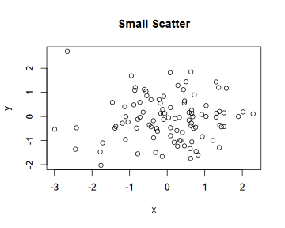

**scatter_small**  
100 points

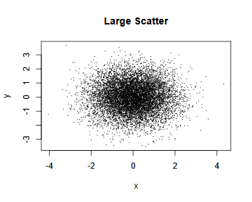

**scatter_large**  
10,000 points

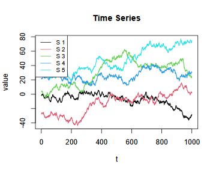

**lines**  
5 time series with legend

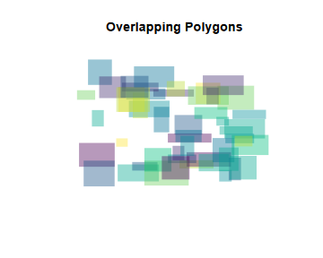

**polygons**  
50 semi-transparent rects

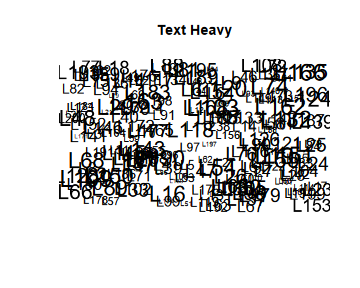

**text_heavy**  
200+ text labels

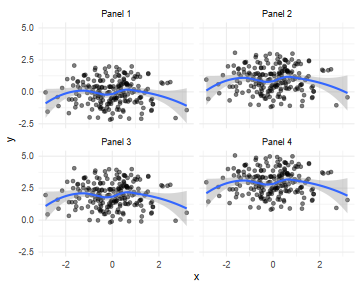

**ggplot_complex**  
Faceted scatter + smooth

## Methodology

Each device renders every test plot using `bench::mark()` with a minimum of 5 iterations. Output file sizes are captured from a separate run.

Raster devices use 720 x 576 px; vector devices use 10 x 8 in (720 x 576 px equivalent at 72 dpi).

The timing tables show the median time and a **ratio** comparing each alternative device to the corresponding base R device (`base::svg`, `base::png`, etc.), so values below 1.0x mean faster than base R.

**A note on Cairo backends:** unigd uses Cairo under the hood for PNG, PDF, and TIFF output. Comparisons with `Cairo::CairoPNG`, `Cairo::CairoPDF`, etc. therefore isolate device pipeline overhead (recording, serialization, file I/O) rather than rasterizer differences.

The charts show individual iteration times as jittered points with a median crossbar, giving a sense of run-to-run variability.

## Environment

Results were generated on **Windows** (x86-64, windows) with **R version 4.5.2 (2025-10-31 ucrt)** at 2026-02-15 23:34 UTC.

**CPU:** Intel(R) Core(TM) i7-10875H CPU @ 2.30GHz

**Package versions:** unigd 0.2.0, bench 1.1.4, svglite 2.2.2, ragg 1.5.0, Cairo 1.7.0, ggplot2 4.0.2

## SVG

| Plot | base::svg | svglite | Cairo::CairoSVG | **unigd svg** |
| --- | --- | --- | --- | --- |
| scatter_small | 6.2 ms | 6.4 ms (1.0x) | 11.4 ms (1.8x) | **5.2 ms (0.8x)** |
| scatter_large | 134 ms | 122 ms (0.9x) | 266 ms (2.0x) | **31.5 ms (0.2x)** |
| lines | 18.0 ms | 27.9 ms (1.6x) | 26.0 ms (1.4x) | **9.8 ms (0.5x)** |
| polygons | 7.5 ms | 8.3 ms (1.1x) | 10.2 ms (1.4x) | **6.8 ms (0.9x)** |
| text_heavy | 42.0 ms | 38.1 ms (0.9x) | 182 ms (4.3x) | **33.6 ms (0.8x)** |
| ggplot_complex | 552 ms | 607 ms (1.1x) | 566 ms (1.0x) | **563 ms (1.0x)** |

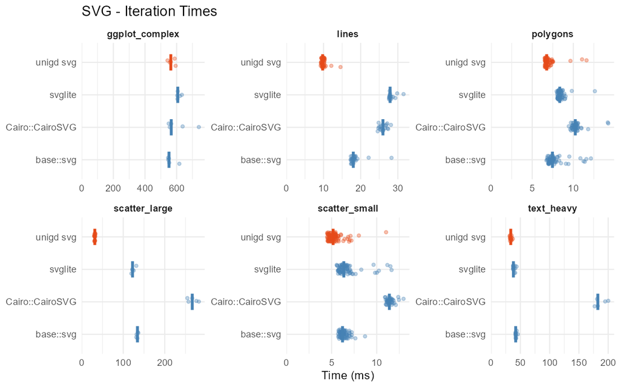

SVG

## PNG

| Plot | base::png | ragg::agg_png | Cairo::CairoPNG | **unigd png** |
| --- | --- | --- | --- | --- |
| scatter_small | 22.0 ms | 25.5 ms (1.2x) | 29.7 ms (1.3x) | **27.9 ms (1.3x)** |
| scatter_large | 108 ms | 43.4 ms (0.4x) | 51.0 ms (0.5x) | **43.4 ms (0.4x)** |
| lines | 76.4 ms | 37.6 ms (0.5x) | 53.2 ms (0.7x) | **46.3 ms (0.6x)** |
| polygons | 25.4 ms | 26.1 ms (1.0x) | 26.7 ms (1.0x) | **27.5 ms (1.1x)** |
| text_heavy | 167 ms | 84.5 ms (0.5x) | 49.3 ms (0.3x) | **59.5 ms (0.4x)** |
| ggplot_complex | 648 ms | 617 ms (1.0x) | 628 ms (1.0x) | **611 ms (0.9x)** |

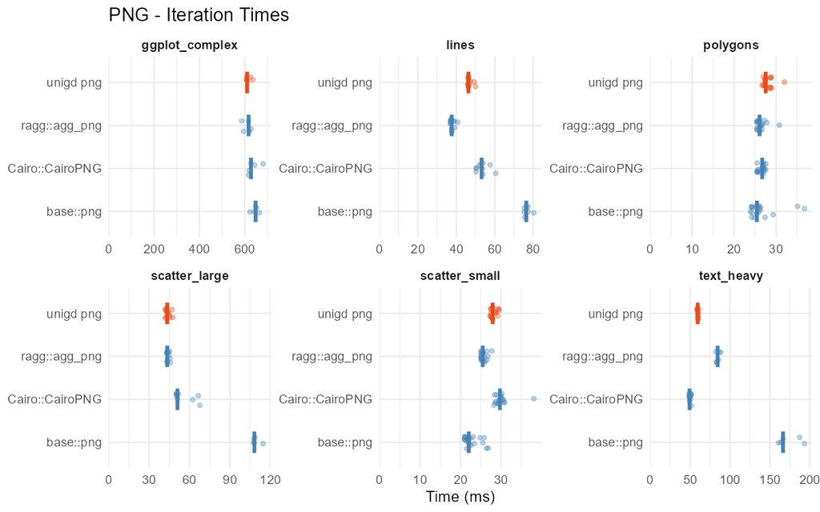

PNG

## PDF

| Plot | base::pdf | Cairo::CairoPDF | **unigd pdf** |
| --- | --- | --- | --- |
| scatter_small | 6.0 ms | 14.5 ms (2.4x) | **9.2 ms (1.5x)** |
| scatter_large | 36.1 ms | 78.7 ms (2.2x) | **75.4 ms (2.1x)** |
| lines | 19.1 ms | 37.8 ms (2.0x) | **30.0 ms (1.6x)** |
| polygons | 6.2 ms | 11.3 ms (1.8x) | **8.4 ms (1.4x)** |
| text_heavy | 3.9 ms | 35.8 ms (9.1x) | **36.9 ms (9.4x)** |
| ggplot_complex | 548 ms | 584 ms (1.1x) | **601 ms (1.1x)** |

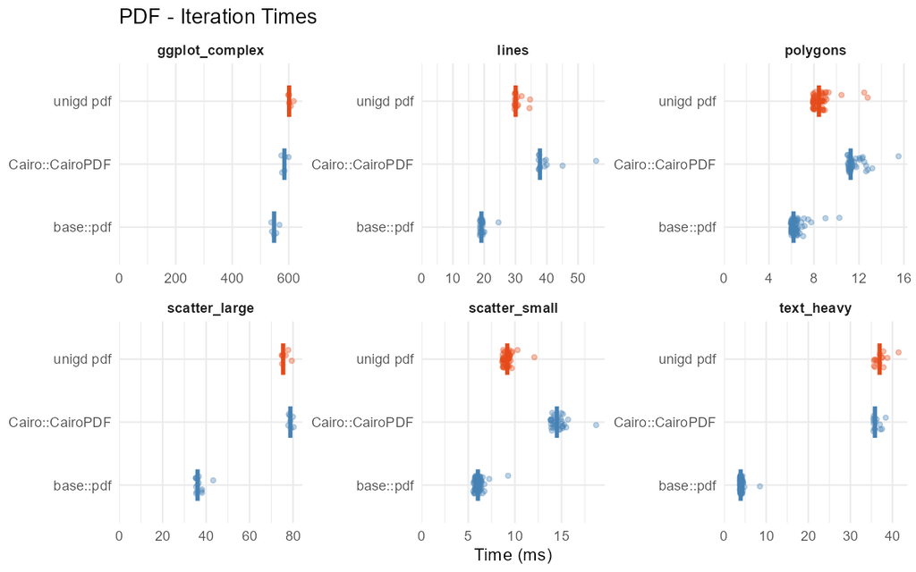

PDF

## TIFF

| Plot | base::tiff | ragg::agg_tiff | **unigd tiff** |
| --- | --- | --- | --- |
| scatter_small | 13.1 ms | 6.5 ms (0.5x) | **19.5 ms (1.5x)** |
| scatter_large | 95.2 ms | 20.3 ms (0.2x) | **33.9 ms (0.4x)** |
| lines | 62.8 ms | 14.1 ms (0.2x) | **37.5 ms (0.6x)** |
| polygons | 12.6 ms | 9.6 ms (0.8x) | **19.6 ms (1.6x)** |
| text_heavy | 143 ms | 61.6 ms (0.4x) | **51.7 ms (0.4x)** |
| ggplot_complex | 647 ms | 595 ms (0.9x) | **575 ms (0.9x)** |

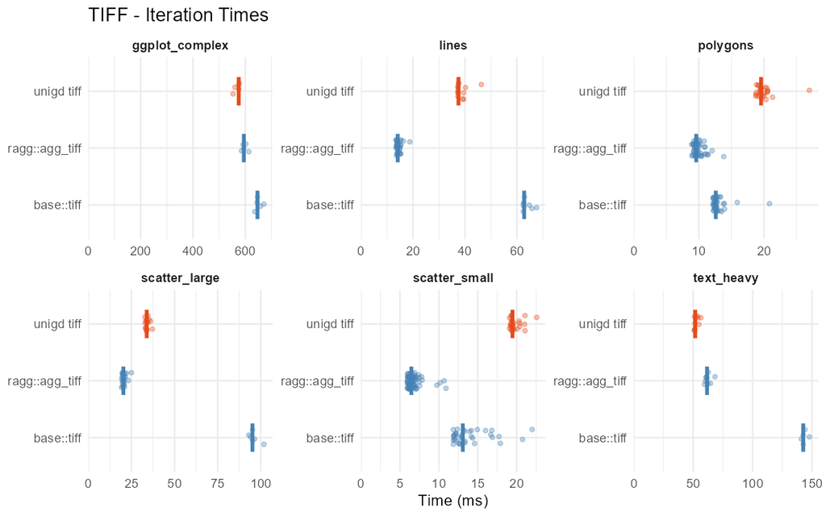

TIFF

## File Sizes

| Format | base | svglite | ragg | Cairo | **unigd** |
| --- | --- | --- | --- | --- | --- |
| SVG | 53.3 KB | 11.9 KB | — | 53.1 KB | 11.5 KB |
| PNG | 4.1 KB | — | 22.8 KB | 25.6 KB | 23.0 KB |
| PDF | 10.3 KB | — | — | 23.3 KB | 23.3 KB |
| TIFF | 1.2 MB | — | 1.2 MB | — | 20.1 KB |

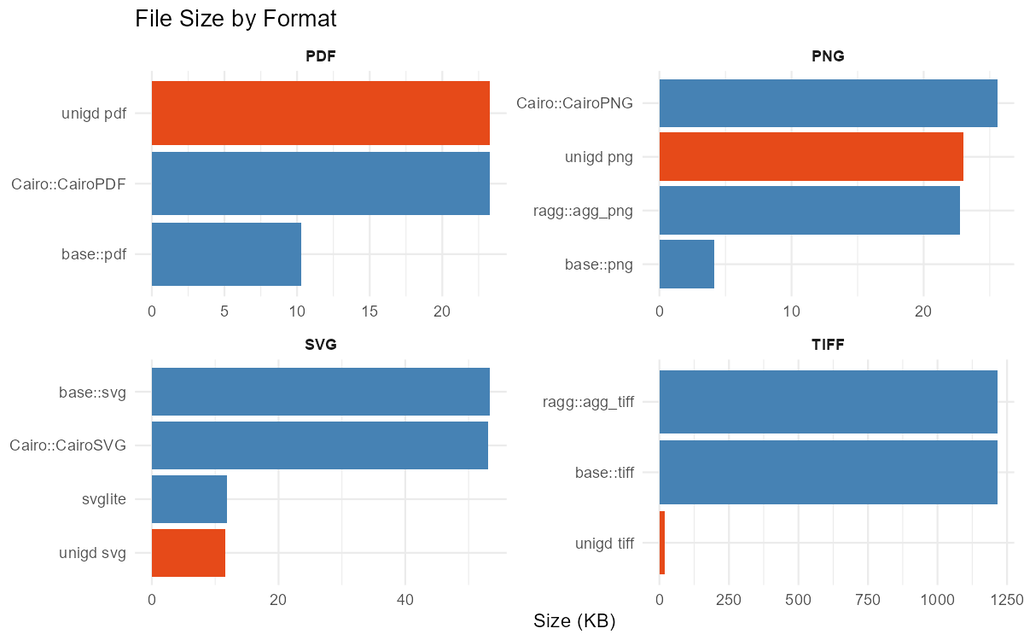

Filesize

## Summary

These results are specific to one machine and configuration.

To reproduce on your own system:

```r
Rscript bench/run.R
```